# IODS course project

# 5 Dimensionality reduction techniques

### 5.1. Data Wrangling and Exploring the data

The Data wrangling part with exploring the data can be found [here](https://github.com/kreikka/IODS-project/blob/master/data/create_human.R). This week’s data consists of Human Development Index (HDI) and gender inequality (GII) related variables by country. The joined and edited data includes 155 observations and the following variables:

| Variable | meaning |
| --- | --- |
| Country | Country name |
| Edu2.FM | Ratio of female and male populations with at least secondary education |
| Labo.FM | Ratio of female and male labor force participation (an estimate of an economy’s active workforce) |
| Edu.Exp | Expected years of education |
| Life.Exp | Life expectancy at birth |
| GNI | Gross National Income (GNI) per Capita |
| Mat.Mor | Maternal mortality ratio |
| Ado.Birth | Adolescent birth rate |
| Parli.F | Female Representation in Parliament, percentage |

Below I’ll load the data and define Country as row names:

```r
# access the libraries needed for the Assignment 5


library(dplyr)
library(readr)
library(corrplot)
library(tibble)
library(ggplot2)
library(GGally)
library(FactoMineR)
library(factoextra)
library(tidyverse)

# load the data created in the Data wrangling:
human <- read_csv(file="C:\\Users\\kuud\\Work Folders\\IODS\\IODS-project\\data\\human.csv")

# Structure of the Data:
str(human)
```

```
## spc_tbl_ [155 × 9] (S3: spec_tbl_df/tbl_df/tbl/data.frame)
##  $ Country  : chr [1:155] "Norway" "Australia" "Switzerland" "Denmark" ...
##  $ Edu2.FM  : num [1:155] 1.007 0.997 0.983 0.989 0.969 ...
##  $ Labo.FM  : num [1:155] 0.891 0.819 0.825 0.884 0.829 ...
##  $ Edu.Exp  : num [1:155] 17.5 20.2 15.8 18.7 17.9 16.5 18.6 16.5 15.9 19.2 ...
##  $ Life.Exp : num [1:155] 81.6 82.4 83 80.2 81.6 80.9 80.9 79.1 82 81.8 ...
##  $ GNI      : num [1:155] 64992 42261 56431 44025 45435 ...
##  $ Mat.Mor  : num [1:155] 4 6 6 5 6 7 9 28 11 8 ...
##  $ Ado.Birth: num [1:155] 7.8 12.1 1.9 5.1 6.2 3.8 8.2 31 14.5 25.3 ...
##  $ Parli.F  : num [1:155] 39.6 30.5 28.5 38 36.9 36.9 19.9 19.4 28.2 31.4 ...
##  - attr(*, "spec")=
##   .. cols(
##   ..   Country = col_character(),
##   ..   Edu2.FM = col_double(),
##   ..   Labo.FM = col_double(),
##   ..   Edu.Exp = col_double(),
##   ..   Life.Exp = col_double(),
##   ..   GNI = col_double(),
##   ..   Mat.Mor = col_double(),
##   ..   Ado.Birth = col_double(),
##   ..   Parli.F = col_double()
##   .. )
##  - attr(*, "problems")=<externalptr>
```

```r
# The first column is Country, and here I'll define the Country names to be the row names:
human <- column_to_rownames(human, "Country")

# Structure of the modified data:
str(human)
```

```
## 'data.frame':    155 obs. of  8 variables:
##  $ Edu2.FM  : num  1.007 0.997 0.983 0.989 0.969 ...
##  $ Labo.FM  : num  0.891 0.819 0.825 0.884 0.829 ...
##  $ Edu.Exp  : num  17.5 20.2 15.8 18.7 17.9 16.5 18.6 16.5 15.9 19.2 ...
##  $ Life.Exp : num  81.6 82.4 83 80.2 81.6 80.9 80.9 79.1 82 81.8 ...
##  $ GNI      : num  64992 42261 56431 44025 45435 ...
##  $ Mat.Mor  : num  4 6 6 5 6 7 9 28 11 8 ...
##  $ Ado.Birth: num  7.8 12.1 1.9 5.1 6.2 3.8 8.2 31 14.5 25.3 ...
##  $ Parli.F  : num  39.6 30.5 28.5 38 36.9 36.9 19.9 19.4 28.2 31.4 ...
```

```r
# Now there is 8 variables instead of nine
```

Next I’ll examine the data graphically.

```r
# summaries of the variables in the data
summary(human)
```

```
##     Edu2.FM          Labo.FM          Edu.Exp         Life.Exp
##  Min.   :0.1717   Min.   :0.1857   Min.   : 5.40   Min.   :49.00
##  1st Qu.:0.7264   1st Qu.:0.5984   1st Qu.:11.25   1st Qu.:66.30
##  Median :0.9375   Median :0.7535   Median :13.50   Median :74.20
##  Mean   :0.8529   Mean   :0.7074   Mean   :13.18   Mean   :71.65
##  3rd Qu.:0.9968   3rd Qu.:0.8535   3rd Qu.:15.20   3rd Qu.:77.25
##  Max.   :1.4967   Max.   :1.0380   Max.   :20.20   Max.   :83.50
##       GNI            Mat.Mor         Ado.Birth         Parli.F
##  Min.   :   581   Min.   :   1.0   Min.   :  0.60   Min.   : 0.00
##  1st Qu.:  4198   1st Qu.:  11.5   1st Qu.: 12.65   1st Qu.:12.40
##  Median : 12040   Median :  49.0   Median : 33.60   Median :19.30
##  Mean   : 17628   Mean   : 149.1   Mean   : 47.16   Mean   :20.91
##  3rd Qu.: 24512   3rd Qu.: 190.0   3rd Qu.: 71.95   3rd Qu.:27.95
##  Max.   :123124   Max.   :1100.0   Max.   :204.80   Max.   :57.50
```

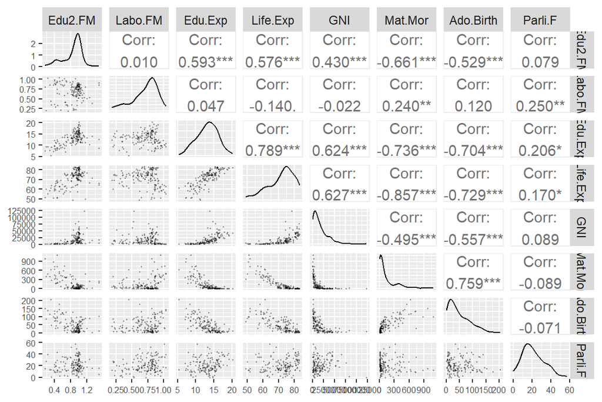

```r
# graphical overview with ggpairs
ggpairs(human, progress = FALSE, lower = list(continuous = wrap("points", alpha = 0.3, size=0.2), combo = wrap("dot", alpha = 0.4, size=0.2))) +
          theme(axis.text=element_text(size=6))
```

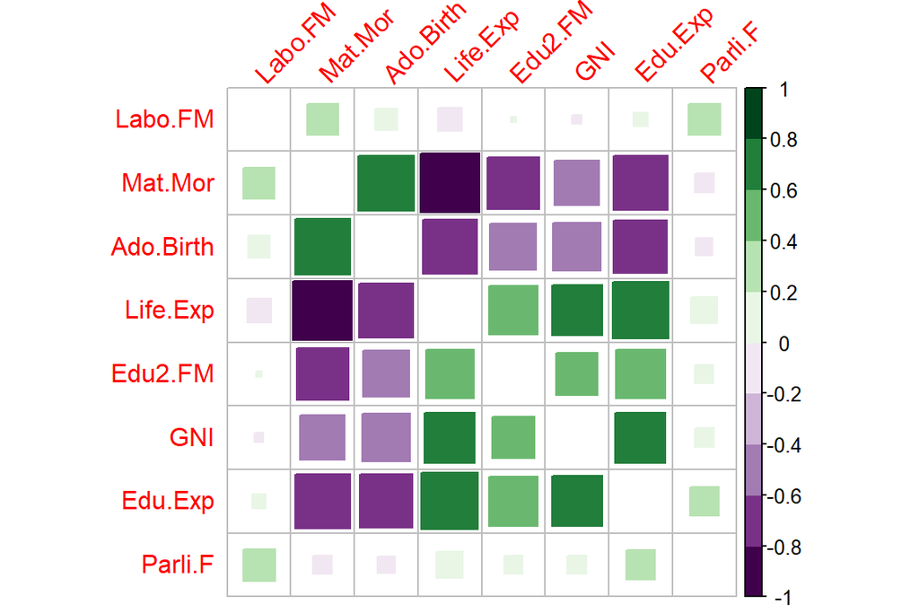

```r
# compute the correlation matrix and visualize it with corrplot
cor_matrix <- cor(human)
corrplot(cor_matrix, method="square", order = "AOE", tl.srt = 45, col = COL2("PRGn", 10), diag = FALSE)
```

We can see that the distributions of the variables vary a lot. The expected years of education (**Edu.Exp**) is the only variable that looks somewhat normally distributed. The distribution of **GNI**, maternal mortality (**Mat.Mor**), adolescent birth rate (**Ado.Birth**) and the percentage of female representatives in parliament (**Parli.F**) are skewed right, meaning low (and medium) values of observations in most of the Countries. For example the maternal mortality rate in most countries is quite low, but higher rates are still prevalent in some of the countries. On the contrary, the distributions of life expectancy (**Life.Exp**), the ratio of female/male labour force participation rate (**Labo.FM**) and the ratio of female/male population with at least secondary education (**Edu2.FM**) are skewed to the left.

The correlations seem intuitive; both maternal mortality and adolescent birth rate correlates negatively with life expectancy, the ratio of female/male population with at least secondary education and expected years of education. They also have a negative correlation with GNI. Maternal mortality rate and adolescent birth rate correlate positively with each other; in countries with less adolescent births, there is also less maternal mortality. Life expectancy correlates positively with expected years of education, GNI and the ratio of female/male secondary school; Countries with higher GNI, more education and equal education between females and males have higher life expectancy. The ratio of females/males participating in labour force seems not to have much correlation with the other variables.

### 5.2. Principal component analysis (PCA)

The principal component analysis (PCA) on the ‘human’ -data is done below:

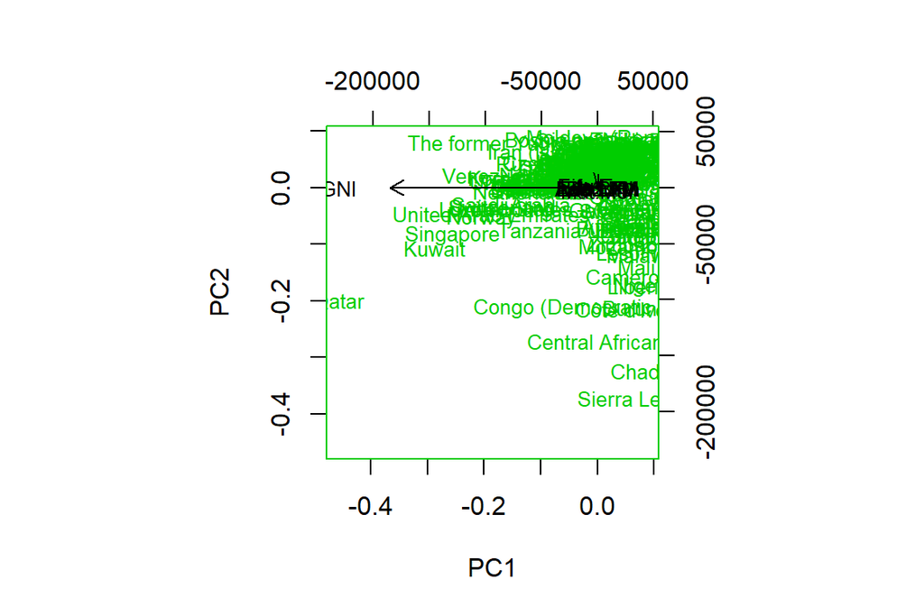

```r
# Principal component analysis (PCA) with the SVD method
pca_human <- prcomp(human)

# a biplot of the principal component representation and the original variables
biplot(pca_human, choices = 1:2, cex = 0.8, col = c("green3", "black"))
```

```r
#print summary
summary(pca_human)
```

```
## Importance of components:
##                              PC1      PC2   PC3   PC4   PC5   PC6    PC7    PC8
## Standard deviation     1.854e+04 185.5219 25.19 11.45 3.766 1.566 0.1912 0.1591
## Proportion of Variance 9.999e-01   0.0001  0.00  0.00 0.000 0.000 0.0000 0.0000
## Cumulative Proportion  9.999e-01   1.0000  1.00  1.00 1.000 1.000 1.0000 1.0000
```

The x-axis displays the first principal component (PC1) and the y-axis the second principal component (PC2). The observations are shown in the plot in green with the 8 variables shown in black. From the summary table we can observe that the PC1 captures almost all the variance while other components have almost no variance. It seems that GNI has the strongest effect in PC1. Qatar is clearly different from other countries, but otherwise the plot is difficult to interpret and the results are quite meaningless.  
Therefore, it is a good idea to try the PCA again with scaled data.

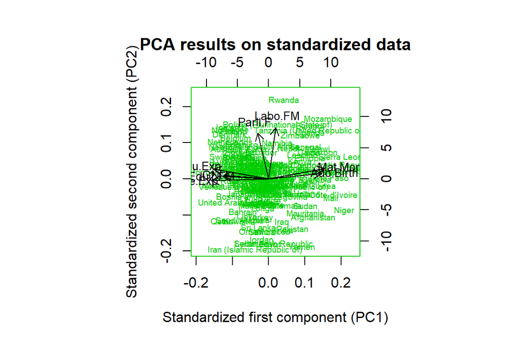

```r
# standardizing the variables
human_std <- scale(human)

# perform principal component analysis (with the SVD method) on the standardized data
pca_human_std <- prcomp(human_std)


# a biplot of the principal component representation
biplot(pca_human_std, choices = 1:2, cex = c(0.6, 0.8), col = c("green3", "black"),
       main = "PCA results on standardized data",
       xlab = "Standardized first component (PC1)",
       ylab = "Standardized second component (PC2)")
```

```r
# print summary
summary(pca_human_std)
```

```
## Importance of components:
##                           PC1    PC2     PC3     PC4     PC5     PC6     PC7
## Standard deviation     2.0708 1.1397 0.87505 0.77886 0.66196 0.53631 0.45900
## Proportion of Variance 0.5361 0.1624 0.09571 0.07583 0.05477 0.03595 0.02634
## Cumulative Proportion  0.5361 0.6984 0.79413 0.86996 0.92473 0.96069 0.98702
##                            PC8
## Standard deviation     0.32224
## Proportion of Variance 0.01298
## Cumulative Proportion  1.00000
```

The new biplot is easier to interpret and the overall variability shows a lot better on a standardized than on a raw data. The extreme value of GNI in Qatar does not have as strong impact on the PC1 in the scaled data. Below is the same plot scaled, so that the country names and clustering can be seen better:

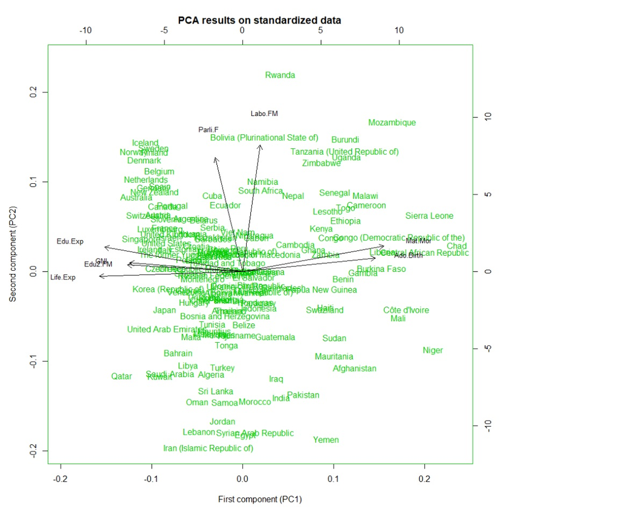

> Upper left: High gender equality and standard of living // Upper right: High gender equality and low standard of living // Lower right: Low gender equality and standard of living // Lower left: Low gender equality and high standard of living

The ratio of female/male labour force participation rate (**Labo.FM**) and the percentage of female representatives in parliament (**Parli.F**) seems to have an impact on PC2 and other variables have more impact on PC1, which is in line with previous correlation exploring (**Parli.F** and **Labo.FM** did not have as much correlation with the other variables). The higher the Maternal mortality (**Mat.Mor**) and adolescent birth rate (**Ado.Birth**), the higher the PC1 value. Again, it is also intuitive, that same countries having higher rates of adolescent births are having problems with maternal mortality rate. For example Sierra Leone, Chad and Congo seem to have high rates of both maternal mortality and adolescent births, as well as low life expectancy (years) and expected years of education. The arrow length of all variables is relatively same. The more developed countries, such as Nordic countries can be found in upper left corner in the figure; Iceland, Sweden, Norway, Finland and Denmark have low adolescent birth rate and maternal mortality due to good health care. At the same time, Nordic countries tend to have good education and relatively equal possibilities for females and males to educate themselves and being employed.

### 5.3. Multiple Correspondence Analysis (MCA)

For this Exercise I’m going to use ‘tea’ data that comes from ‘FactorMineR’ package. The data includes 300 observations and 36 variables on how, why and where the individuals drink tea. First I’ll load and explore the data:

```r
# Reading the data and converting the character variables to factors:
tea <- read.csv("https://raw.githubusercontent.com/KimmoVehkalahti/Helsinki-Open-Data-Science/master/datasets/tea.csv", stringsAsFactors = TRUE)

# viewing the data and exploring the structure and dimensions
# View(tea)
str(tea)
```

```
## 'data.frame':    300 obs. of  36 variables:
##  $ breakfast       : Factor w/ 2 levels "breakfast","Not.breakfast": 1 1 2 2 1 2 1 2 1 1 ...
##  $ tea.time        : Factor w/ 2 levels "Not.tea time",..: 1 1 2 1 1 1 2 2 2 1 ...
##  $ evening         : Factor w/ 2 levels "evening","Not.evening": 2 2 1 2 1 2 2 1 2 1 ...
##  $ lunch           : Factor w/ 2 levels "lunch","Not.lunch": 2 2 2 2 2 2 2 2 2 2 ...
##  $ dinner          : Factor w/ 2 levels "dinner","Not.dinner": 2 2 1 1 2 1 2 2 2 2 ...
##  $ always          : Factor w/ 2 levels "always","Not.always": 2 2 2 2 1 2 2 2 2 2 ...
##  $ home            : Factor w/ 2 levels "home","Not.home": 1 1 1 1 1 1 1 1 1 1 ...
##  $ work            : Factor w/ 2 levels "Not.work","work": 1 1 2 1 1 1 1 1 1 1 ...
##  $ tearoom         : Factor w/ 2 levels "Not.tearoom",..: 1 1 1 1 1 1 1 1 1 2 ...
##  $ friends         : Factor w/ 2 levels "friends","Not.friends": 2 2 1 2 2 2 1 2 2 2 ...
##  $ resto           : Factor w/ 2 levels "Not.resto","resto": 1 1 2 1 1 1 1 1 1 1 ...
##  $ pub             : Factor w/ 2 levels "Not.pub","pub": 1 1 1 1 1 1 1 1 1 1 ...
##  $ Tea             : Factor w/ 3 levels "black","Earl Grey",..: 1 1 2 2 2 2 2 1 2 1 ...
##  $ How             : Factor w/ 4 levels "alone","lemon",..: 1 3 1 1 1 1 1 3 3 1 ...
```

[output cut: 22 more lines]

```r
dim(tea)
```

```
## [1] 300  36
```

```r
summary(tea)
```

```
##          breakfast           tea.time          evening          lunch
##  breakfast    :144   Not.tea time:131   evening    :103   lunch    : 44
##  Not.breakfast:156   tea time    :169   Not.evening:197   Not.lunch:256
##
##
##
##
##
##         dinner           always          home           work
##  dinner    : 21   always    :103   home    :291   Not.work:213
##  Not.dinner:279   Not.always:197   Not.home:  9   work    : 87
##
##
##
##
##
##         tearoom           friends          resto          pub
##  Not.tearoom:242   friends    :196   Not.resto:221   Not.pub:237
##  tearoom    : 58   Not.friends:104   resto    : 79   pub    : 63
##
##
##
##
##
##         Tea         How           sugar                     how
##  black    : 74   alone:195   No.sugar:155   tea bag           :170
##  Earl Grey:193   lemon: 33   sugar   :145   tea bag+unpackaged: 94
##  green    : 33   milk : 63                  unpackaged        : 36
##                  other:  9
##
##
##
##                   where                 price          age        sex
##  chain store         :192   p_branded      : 95   Min.   :15.00   F:178
##  chain store+tea shop: 78   p_cheap        :  7   1st Qu.:23.00   M:122
##  tea shop            : 30   p_private label: 21   Median :32.00
##                             p_unknown      : 12   Mean   :37.05
##                             p_upscale      : 53   3rd Qu.:48.00
##                             p_variable     :112   Max.   :90.00
##
```

[output cut: 25 more lines]

```
##  feminine    :129   Not.sophisticated: 85   No.slimming:255   exciting   :116
##  Not.feminine:171   sophisticated    :215   slimming   : 45   No.exciting:184
##
##
##
##
##
##         relaxing              effect.on.health
##  No.relaxing:113   effect on health   : 66
##  relaxing   :187   No.effect on health:234
##
##
##
##
##
```

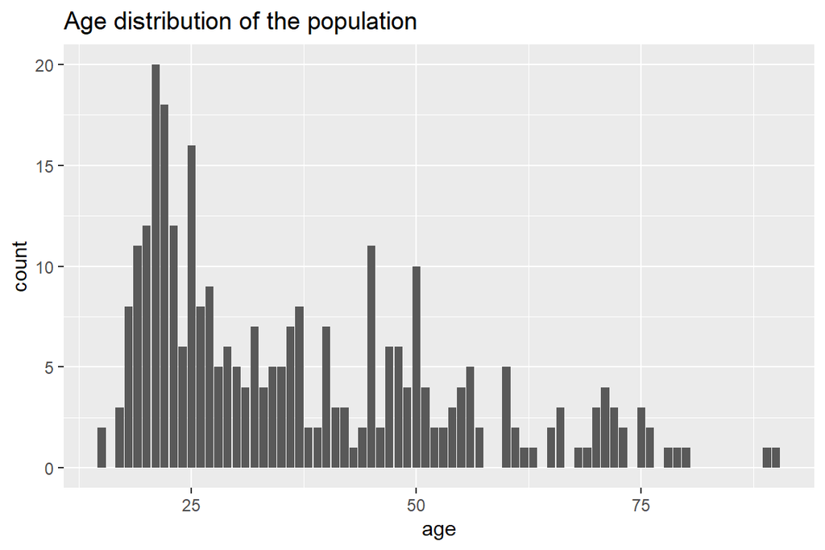

```r
# Plots on the age distribution of the population and general information about what tea and how they drink their tea:

p1 <- ggplot(data = tea, aes(x = age, fill = age)) +
  geom_bar() +
  ggtitle("Age distribution of the population")

p2 <- ggplot(data = tea, aes(x = frequency, fill = frequency)) +
  geom_bar() +
  ggtitle("Frequency of drinking tea")

p3 <- ggplot(data = tea, aes(x = Tea, fill = Tea)) +
  geom_bar() +
  ggtitle("Tea types")

p4 <- ggplot(data = tea, aes(x = how, fill = how)) +
  geom_bar() +
  ggtitle("Using unpackaged tea or tea bags")

p5 <- ggplot(data = tea, aes(x = sugar, fill = sugar)) +
  geom_bar() +
  ggtitle("Using sugar in tea")

p6 <- ggplot(data = tea, aes(x = How, fill = How)) +
  geom_bar() +
  ggtitle("Using milk, lemon or other additions with tea")

p7 <- ggplot(data = tea, aes(x = where, fill = where)) +
  geom_bar() +
  ggtitle("Typical place to buy tea")

p1
```